# Praca Domowa 01

Kamil Kmita

7 października 2017

# Artykuł

Artykuł, do którego przygotowałem wizualizacje, to komentarz Marcina Wrońskiego dotyczący optymistycznych głosów łączących wzrost gospodarczy w Unii Europejskiej z poprawą sytuacji ekonomicznej obywateli EU (http://krytykapolityczna.pl/gospodarka/europa-potrzebuje-podwyzki/). Autor pozostaje sceptyczny wobec takiego twierdzenia i punktuje w artykule różne symptomy tego, że wzrost PKB nie przekłada się na wzrost dobrobytu obywateli.

Wroński nie przedstawia żadnych grafik, wobec tego postanowiłem zwizualizować poniższy fragment artykułu dotyczący relacji pomiędzy wzrostem PKB oraz płac realnych w ujęciu realnym.

*Od 2013 roku faktycznie możemy mówić o wzroście PKB Unii Europejskiej, a od 2014 roku o wzroście PKB strefy euro. Jego tempo pozostawia jednak wiele do życzenia. Dopiero w 2015 roku realna wartość PKB strefy euro odzyskała poziom sprzed kryzysu. Produkt Krajowy Brutto Portugalii, Finlandii, Włoch i Grecji wciąż jest poniżej stanu sprzed kryzysu. Teoretycznie w roku 2016 PKB po raz pierwszy wzrosło we wszystkich krajach Unii Europejskiej, jednakże w przypadku Grecji z dynamiką wynoszącą… 0,00%, trafniej byłoby raczej mówić, że po prostu nie spadło kolejny rok z rzędu.*

*Rachityczny wzrost europejskiego PKB nie przekłada się na wzrost płac realnych. W dziesięciu państwach Unii Europejskiej realna wartość wynagrodzeń wciąż jest niższa niż w roku 2009. Najwyraźniejsze różnice są w Grecji (spadek o 23%), na Cyprze (spadek o 13%), w Portugalii (-8,6%), Chorwacji (-5,8%) i Hiszpanii (-5,5%). Pozostałe państwa, w których zarabia się mniej niż dekadę temu, to: Austria, Finlandia, Belgia, Wielka Brytania i Włochy.*

# Źródło danych

Informacje o płacach pobrałem z tabeli [Gross Average Monthly Wages by Country and Year](http://w3.unece.org/PXWeb2015/pxweb/en/STAT/STAT__20-ME__3-MELF/60_en_MECCWagesY_r.px/?rxid=b5436f97-1001-4287-896f-f10ed2d4970a) ze strony UNECE -stamtąd ściągnąłem także indeksator inflacji [Price Indices](http://w3.unece.org/PXWeb2015/pxweb/en/STAT/STAT__20-ME__4-MEPI/0_en_MECCPriceInterestY_r.px/?rxid=fca01382-d0a8-465f-932f-f65345bd058a).

Informacje o PKB w ujęciu nominalnym uzyskałem ze strony Eurostat - aby dysponować danymi w ujęciu realnym, użyłem przeważyłem dane indeksatorem inflacji z UNECE.

Ponadto, użyłem danych o odsetku osób pracujących, ale pozostających w zagrożeniu ubóstwem (at-risk-of-poverty). Są to dane Eurostatu, a osoba zagrożona ubóstwem to taka, której zarobki nie przekraczają 60% mediany zarobków w danym kraju. Pogrupowałem państwa według kwartyli na 4 grupy ‘workpoverty’.

# Wizualizacje

**Wroński w artykule mówi o relacjach rozważanych wielkości pomiędzy rokiem 2009 oraz 2016, wobec tego poniższe wizualizacje pokazują procentową zmianę PKB oraz przeciętnych płac w ujęciu realnym pomiędzy rokiem 2009 oraz 2016.**

## PKB ~ płace

Liniowa zależność zdaje się być zaburzona jedynie przez kilka państw Europy Zachodniej (obserwacje odstające: Ireland, Luxembourg, United Kingdom) oraz Bułgarię - obserwację wpływową.

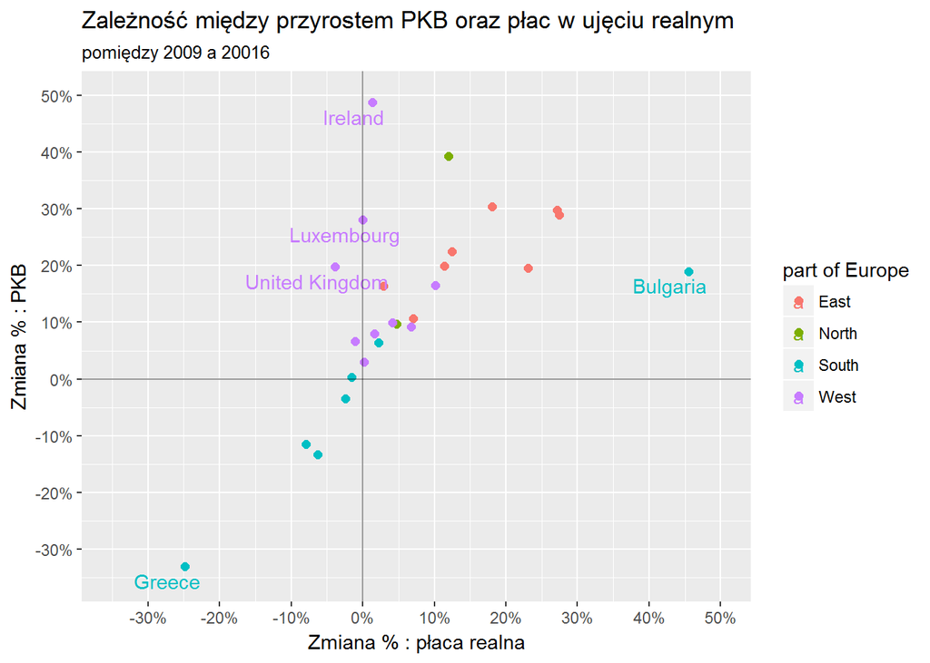

## PKB~płace w podziale na regiony geograficzne

Na poniższym wykresie rozbiłem populację państw UE na subpopulacje ze względu na region geograficzny. Dzięki temu wyraźnie widać, że zarówno wśród państw Wschodu jak i Południa obserwujemy silną liniową zależność (z obserwacją odstającą w subpopulacji państw Południa), natomiast efekt liniowości w całej populacji zaburzony był poprzez państwa Zachodu: te w większości zanotowały znacznie silniejszy przyrost PKB niż płac, co może charakteryzować pewne nasycenie dobrobytu wśród obywateli państw wysoko rozwiniętych.

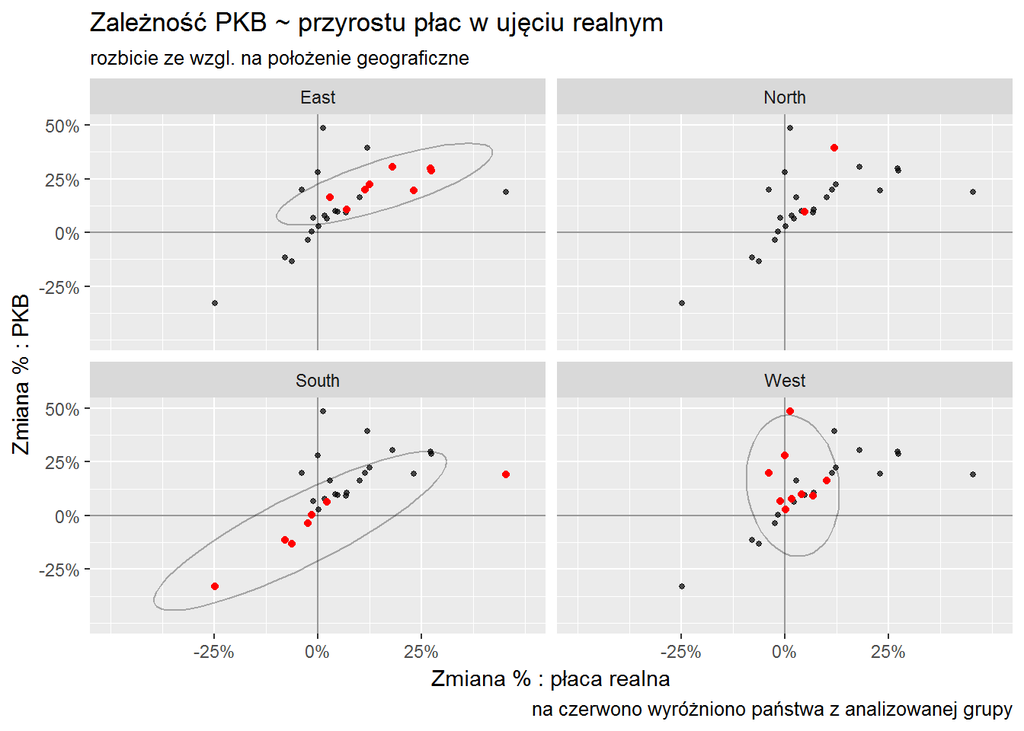

## płace~grupa ‘workpoverty’

Warto zobaczyć, czy informacja o odsetku osób pracujących zagrożonych ubóstwem (dane na 2015 rok) wnosi jakąś wartość dodaną do analiz.

Poniższy wykres pokazuje, że - przeciętnie rzecz biorąc - płace realne rosły silniej wraz z przynależnością pańśtwa do coraz gorszej grupy ‘workpoverty’ - jest to wniosek obowiązujący dla 3 pierwszych grup. Trend rosnący zostaje przełamany dla 4 grupy, ‘najuboższej’. Naniesienie punktów na boxploty pokazuje jednak, że jedynym słusznym wnioskiem jest informacja o tym, że wraz ze wzrostem osób zagrożonych ubóstwem mimo pracy zwiększa się wariancja rozkładu zmian płac realnych. Pokazuje to pewną stabilność wśród rozwiniętych gospodarczo społeczeństw i ‘huśtawkę’ sytuacji wśród tych, spora część osób jest wciąż zagrożona ubóstwem.

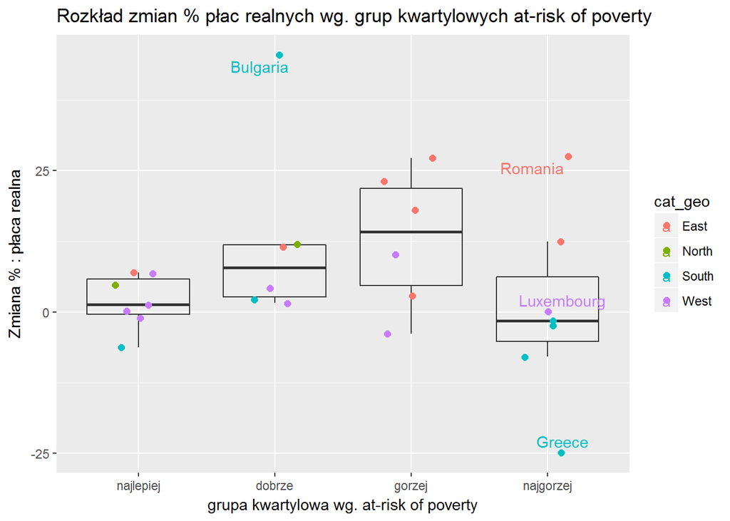

## płace~grupa ‘workpoverty’ oraz rejon geograficzny

Do ciekawych wniosków prowadzi także wykres, który ukazuje omówioną przed chwilą relację w podziale na rejon geograficzny Europy.

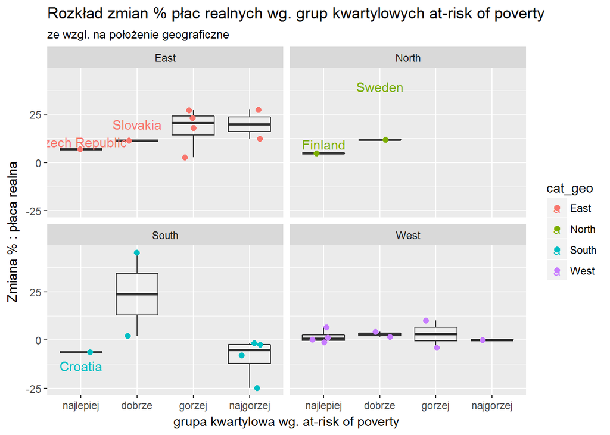